# Capsule 1 - Repérer tendance et saisonnalité

MQT-2101 - Analyse et modélisation des données

## Pourquoi ça compte

Comment distinguer la tendance du motif saisonnier?

Une direction doit distinguer tendance générale et variations saisonnières pour planifier l’année.

## Objectifs de la capsule

- Définir l’unité et la période.
- Lire une tendance, un motif saisonnier et un écart à la tendance.
- Explorer le passé avant de comparer.

## Deux séries fictives, deux décisions

Guidé

ventes et planification annuelle

Transfert

ventes avec contexte commercial variable

$ CA

dollars canadiens par mois

## Séparer avant de choisir

2020 à 2024

60 mois d’apprentissage

2025

12 mois de validation

Origine

fin de décembre 2024

## Lire la trajectoire

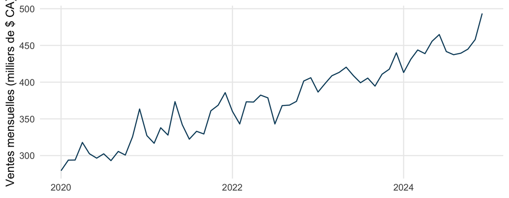

## Comparer les mêmes mois entre années

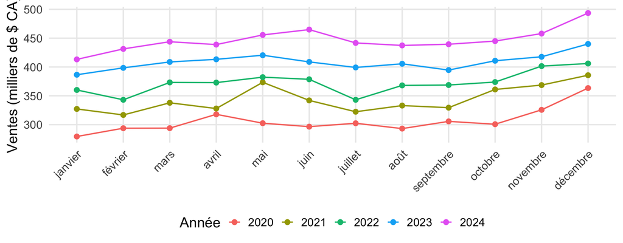

## Deux structures peuvent coexister

- La tendance fait évoluer le niveau général.
- La saisonnalité revient selon un calendrier connu.
- Une seule année ne démontre pas la répétition.

## Mesurer un écart à la tendance

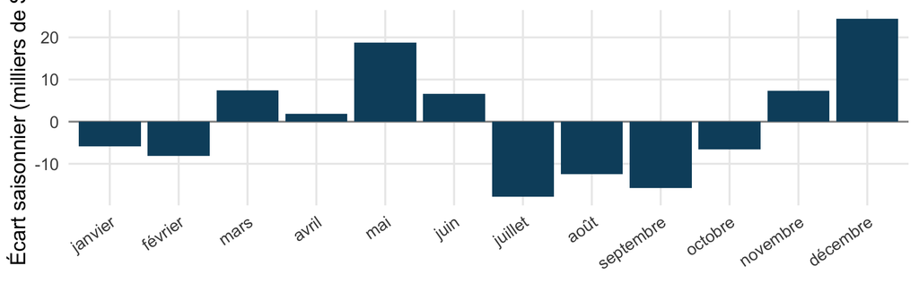

En décembre, la composante saisonnière ajoute environ 24 400 $ à la tendance estimée.

## Décrire sans inventer une cause

Des ventes élevées pendant un mois peuvent aussi refléter un événement commercial ou un changement d’activité.

La tendance centrée se calcule à partir des mois voisins. Aux extrémités, la fenêtre est incomplète.

## À retenir

Temps

conserver l’ordre

Saison

lire un écart à la tendance

Limite

un graphique ne démontre pas une cause

## Production autonome 8.1

Sur les 60 mois d’apprentissage, tracez les ventes dans le temps et les profils mensuels par année. Nommez les unités, décrivez une hausse et un motif récurrent, puis expliquez ce que ces graphiques ne permettent pas d’attribuer à une cause. À partir de la décomposition fournie, interprétez un écart saisonnier mensuel et une limite.

Cette production se réalise une seule fois dans le rapport guidé.

### Auto-vérification

- J’ai limité l’exploration à 2020 à 2024.
- Mes axes indiquent les mois et les dollars canadiens.
- Je distingue tendance, répétition et explication causale.
- J’interprète un écart saisonnier et une limite de la décomposition.